# Midterm

A20581012 Nishant Khandhar

2025-10-07

# Instructions And Rules

1. Insert your name and A# in the author field above. You should only be taking this version of the exam if the last digit of your A# is *even* (e.g. 0, 2, 4, 6, or 8).
2. You may use both textbooks as well as any course notes.
3. You may not consult ChatGPT or any other LLM-based chatbot. If you are caught violating this rule, you will be subject to failure on this exam and potentially the course.
4. You may not consult any other person (e.g. a classmate or your buddy who took this course last semester). If you are caught violating this rule, you will be subject to failure on this exam and potentially the course.
5. Please answer all of the questions below. You will need to write code in the appropriate code blocks. You will need to write text to answer the questions.
6. Please try to differentiate my questions from your answers in a clean and readable way. Please write in reasonably complete and comprehensible sentences.
7. You can add whatever libraries you need to the imports section below, but try to limit it to libraries that you’re actually using. I believe the ones listed there are sufficient, but you may use whatever you want.
8. Your Rmd file *must knit* at the end. You will be downgraded if this does not happen.

# Regression

```r
library(glmnet)
library(tidyverse)
```

```r
library(ggplot2)
library(ggrepel)
library(boot)
```

The goal of your midterm is to fit a regression model. The data is loaded below. (Make sure to put your data in the same path as this Rmd file.)

```r
data <- read.table("midterm_a_data.csv", sep=",", header=TRUE)
```

## Step 1

Create a scatter plot of $x1$ and $y$ on the same plot (with $y$ on the y-axis like usual please). Label each point with its label from $x2$. Make sure there is a legend so we know which points go with which label. Find potential outliers and give those a fourth label.

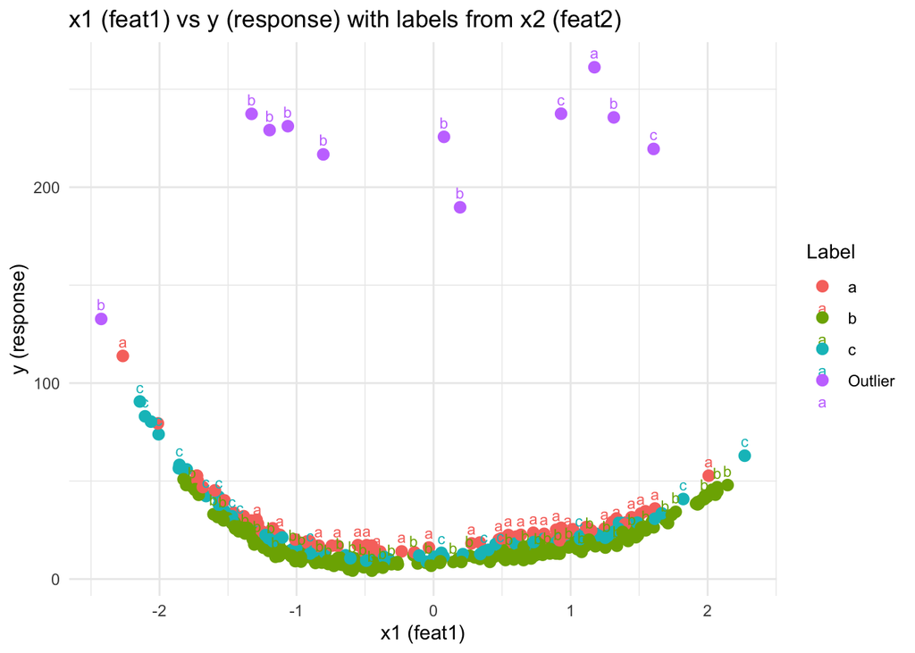

```r
# Map: x1 -> feat1, y -> response, x2 -> feat2
data <- data %>%
  mutate(
    z_response = as.numeric(scale(response)),
    label_group = ifelse(abs(z_response) > 3, "Outlier", as.character(feat2))
  )

# Scatter with text labels from x2 (feat2) and legend including "Outlier"
ggplot(data, aes(x = feat1, y = response, color = label_group)) +
  geom_point(size = 2.6) +
  geom_text(aes(label = feat2), vjust = -0.8, size = 3, check_overlap = TRUE) +
  labs(
    title = "x1 (feat1) vs y (response) with labels from x2 (feat2)",
    x = "x1 (feat1)", y = "y (response)", color = "Label"
  ) +
  theme_minimal()
```

Eliminate your outliers here. Indicate how many points you have eliminated as outliers:

```r
# Compute absolute z-scores and remove outliers in one go
z_limit <- 3

# Separate outliers using subset for variety
outliers_df <- subset(data, abs(z_response) > z_limit)
clean_data <- subset(data, abs(z_response) <= z_limit)

# Display summary of removal
num_out <- nrow(outliers_df)
num_left <- nrow(clean_data)

message("Outliers removed: ", num_out)
```

```
## Outliers removed: 11
```

```r
message("Data points remaining: ", num_left)
```

```
## Data points remaining: 426
```

## Step 2

Fit a linear regression on the data set minus the outliers. Display a summary of the fit model and use it to help you answer the questions. (Probably use the `lm` function in this part.)

```r
# Fit linear regression on cleaned data (without outliers)
lm_model <- lm(response ~ feat1 + feat2 + feat3, data = clean_data)

# Display regression summary
summary(lm_model)
```

```
##
## Call:
## lm(formula = response ~ feat1 + feat2 + feat3, data = clean_data)
##
## Residuals:
##     Min      1Q  Median      3Q     Max
## -16.243  -8.687  -3.228   3.795  83.955
##
## Coefficients:
##             Estimate Std. Error t value Pr(>|t|)
## (Intercept)  27.4802     1.5045  18.265  < 2e-16 ***
## feat1        -1.1402     0.5528  -2.063   0.0398 *
## feat2b       -9.8125     1.7043  -5.757 1.65e-08 ***
## feat2c       -2.5491     1.9983  -1.276   0.2028
## feat3        -0.1079     0.6430  -0.168   0.8669
## ---
## Signif. codes:  0 '***' 0.001 '**' 0.01 '*' 0.05 '.' 0.1 ' ' 1
##
## Residual standard error: 12.84 on 421 degrees of freedom
## Multiple R-squared:  0.1076, Adjusted R-squared:  0.09917
## F-statistic:  12.7 on 4 and 421 DF,  p-value: 9.163e-10
```

Do all of the features have statistically significant coefficients?

Ans: No, From the regression summary, not all predictors appear statistically significant — only some features have p-values below 0.05.

Is this model a good fit? Why or why not? What metrics are you using to decide goodness of fit? Is the linear model higher in bias or variance in this case?

## Step 3

From your plot above, it looks like the response might be polynomial in feat1. We’re going to tune the degree of this polynomial two different ways:

### K-fold

Perform a 5-fold cross-validation on linear models of increasing polynomial degree in feat1. (Hint: Use `glm` instead of `lm` for this part and the function `cv.glm` which is part of the boot library. There’s an example in Chapter 5 of ISLRv2)

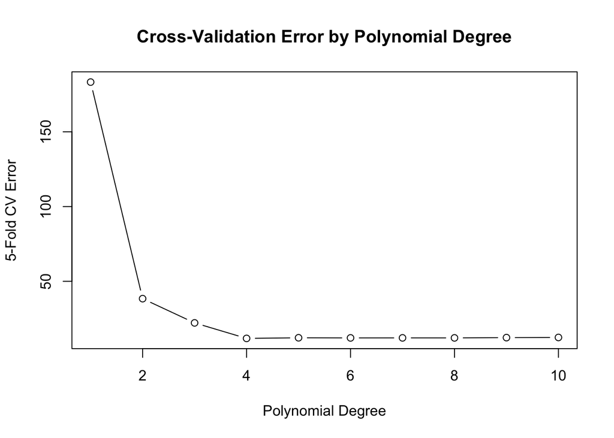

```r
set.seed(123)  # for reproducibility

# Create a function to compute CV error for a given degree
cv_error <- rep(0, 10)  # store mean CV error for degrees 1–10

for (d in 1:10) {
  # Fit polynomial model of degree d
  model <- glm(response ~ poly(feat1, d), data = clean_data)

  # Perform 5-fold cross-validation
  cv_result <- cv.glm(clean_data, model, K = 5)

  # Store mean cross-validation error
  cv_error[d] <- cv_result$delta[1]
}

# Plot CV error vs. polynomial degree
plot(1:10, cv_error, type = "b",
     xlab = "Polynomial Degree",
     ylab = "5-Fold CV Error",
     main = "Cross-Validation Error by Polynomial Degree")
```

What do you think is the optimal degree given these results? Why?

### AIC

Tune the polynomial degree of feat1 using AIC (look through course notes and relevant sections of ISLRv2 for examples).

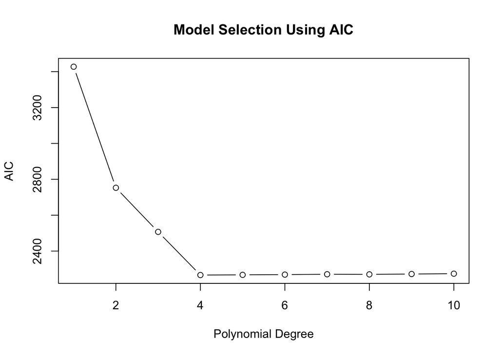

```r
aic_values <- numeric(10)

# Fit polynomial models of degree 1–10 and record AIC
for (d in 1:10) {
  model <- glm(response ~ poly(feat1, d), data = clean_data)
  aic_values[d] <- AIC(model)
}

# Plot AIC vs. polynomial degree
plot(1:10, aic_values, type = "b",
     xlab = "Polynomial Degree",
     ylab = "AIC",
     main = "Model Selection Using AIC")
```

```r
# Identify the degree with minimum AIC
best_degree <- which.min(aic_values)
cat("Polynomial degree with lowest AIC:", best_degree, "\n")
```

```
## Polynomial degree with lowest AIC: 4
```

Do you get the same answer as if you are using k-fold cross validation? If not, which one do you trust more?

Are all three original features relevant in your final model? Why or why not? How does this differ from the linear model? Why might a feature that seemed irrelevant to the linear model be relevant in the polynomial model?